# Quick comparison of CNS Signal exposures estimated from `sigfit` and `deconstructSigs`

SJ Spielman

2022

#### Files and paths

```r
`%>%` <- dplyr::`%>%`

# Path to root of project and local analysis module
proj_root_path <- file.path( rprojroot::find_root(rprojroot::has_dir(".git")) )
analysis_path <- file.path(proj_root_path, "analyses", "mutational-signatures")

# Fitted files:
sigfit_fitted_file <- file.path(analysis_path, "results", "fitted_exposures_signal-cns_sigfit.rds")
decon_fitted_file  <- file.path(analysis_path, "results", "fitted_exposures_signal-cns_deconstructSigs.rds")
```

We read in the fitted signatures and obtain workable tibbles for `sigfit` and `deconstructSigs` results:

```r
sigfit_rds <- readr::read_rds(sigfit_fitted_file) # contains both mean and lower/upper bounds
decon_rds <- readr::read_rds(decon_fitted_file)


# sigfit mean exposures into a tibble
sigfit_mean <- sigfit_rds$mean
sigfit_exposures <- sigfit_mean %>%
  as.data.frame() %>%
  tibble::rownames_to_column("sample_id") %>%
  tibble::as_tibble()  %>%
  dplyr::mutate(type = "sigfit")


# deconstructSigs means exposures into a tibble
decon_mean <- lapply(decon_rds, "[[", "weights")
decon_exposures <- do.call(rbind, decon_mean) %>%
  tibble::rownames_to_column("sample_id") %>%
  tibble::as_tibble() %>%
  dplyr::mutate(type = "decon")
```

Now we compare the results of the two methods. Overall, they are reasonable consistent, so we’ll proceed to visualize the `deconstructSigs` results below.

```r
# wrangle to combine data
data_compare_types <- dplyr::full_join(sigfit_exposures, decon_exposures) %>%
  tidyr::gather(-sample_id, -type, key = "signature", value = "weight") %>%
  tidyr::spread(key = "type", value = "weight")
# Create a second column for sigfit FILTERED to recommended >0.01 lower bound
lower_bound <- sigfit_rds$lower_95
data_compare_types <- lower_bound %>%
  as.data.frame() %>%
  tibble::rownames_to_column("sample_id") %>%
  tibble::as_tibble() %>%
  tidyr::gather(-sample_id, key = "signature", value = "sigfit_lb") %>%
  dplyr::right_join(data_compare_types) %>%
  dplyr::mutate(sigfit_lb_OK = sigfit_lb >= 0.01)
```

First, let’s visualize the results where we do not filter `sigfit` results, where the red line is equality $Y=X$.

As is written in `sigfit` [vignette](https://rdrr.io/github/kgori/sigfit/f/vignettes/sigfit_vignette.Rmd):

> In practice, ‘sufficiently non-zero’ means that the lower end of the Bayesian HPD interval (see the previous section) is above a threshold value close to zero (by default 0.01, and adjustable via the thresh argument).

The plot below does NOT perform this justification where we collapse all lower bound < 0.01 to have a mean exposure of 0. Instead, points are colored based on whether `sigfit` feels these are “sufficiently non-zero” (blue/TRUE), vs effectively zero (red/FALSE).

Note further we see some points which are all at 0 for `deconstructSigs`. They [write](https://genomebiology.biomedcentral.com/articles/10.1186/s13059-016-0893-4),

> Finally, the weights W are normalized between 0 and 1 and any signature with $W_i$ <6% is excluded. This 6 % threshold was chosen by randomly generating tumors in silico whose mutational profiles were perturbed to be distant from the ideal theoretical sample.

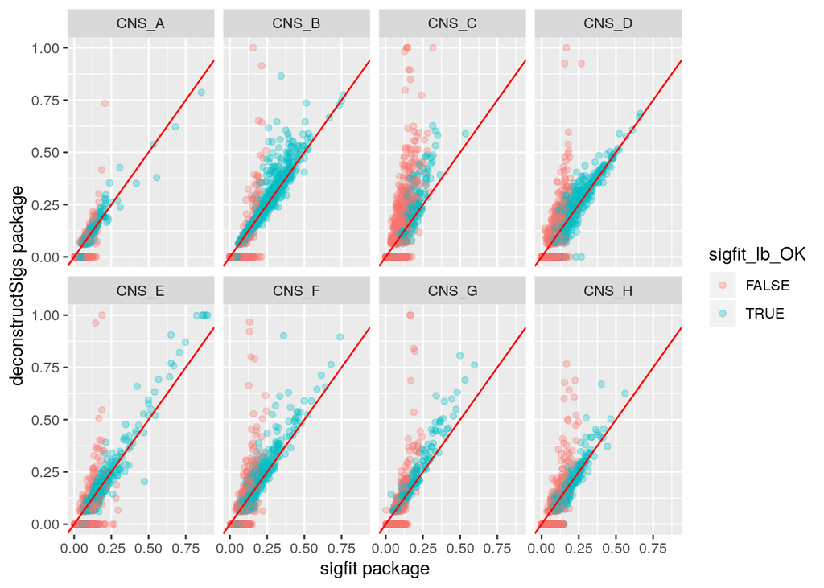

```r
data_compare_types %>%
  ggplot2::ggplot() +
  ggplot2::aes(x = sigfit, y = decon, color = sigfit_lb_OK) +
  ggplot2::geom_point(alpha = 0.3) +
  ggplot2::geom_abline(color = "red") +
  ggplot2::facet_wrap(~signature, nrow = 2) +
  ggplot2::labs(x = "sigfit package", y = "deconstructSigs package")
```

If we *do* change the `sigfit` according to 0.01 lower bound recommendation, we see the FALSE (red) `sigfit` estimates now lining up at 0, as expected.

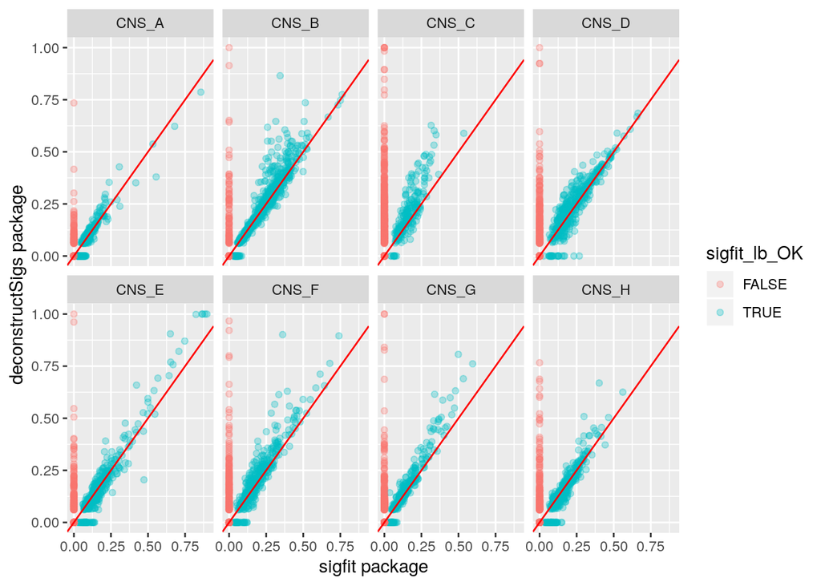

```r
data_compare_types_filter <- data_compare_types %>%
  dplyr::mutate(sigfit = dplyr::if_else(sigfit_lb_OK, sigfit, 0))

data_compare_types_filter %>%
  ggplot2::ggplot() +
  ggplot2::aes(x = sigfit, y = decon, color = sigfit_lb_OK) +
  ggplot2::geom_point(alpha = 0.3) +
  ggplot2::geom_abline(color = "red") +
  ggplot2::facet_wrap(~signature, nrow = 2) +
  ggplot2::labs(x = "sigfit package", y = "deconstructSigs package")
```

We also calculate correlations (pearson and spearman rank) between methods for each signature, with and without the `sigfit` filtering. Correlations are in alphabetical order for signatures A-H.

```r
# First,
perform_correlations_nofilter <- function(signature_name, cor_method) {
  cor(
    data_compare_types$decon[data_compare_types$signature == signature_name],
    data_compare_types$sigfit[data_compare_types$signature == signature_name],
    method = cor_method
  )
}

perform_correlations_filter <- function(signature_name, cor_method) {
  cor(
    data_compare_types_filter$decon[data_compare_types_filter$signature == signature_name],
    data_compare_types_filter$sigfit[data_compare_types_filter$signature == signature_name],
    method = cor_method
  )
}


### PEARSON.
# filtered, unfiltered
purrr::map2_dbl(unique(data_compare_types$signature), "pearson", perform_correlations_filter)
```

```
[1] 0.7587967 0.8401990 0.3260125 0.7280276 0.8141882 0.7064913 0.6769721
[8] 0.6426524
```

```r
purrr::map2_dbl(unique(data_compare_types$signature), "pearson", perform_correlations_nofilter)
```

```
[1] 0.8499254 0.8982239 0.6888705 0.8125591 0.8671871 0.8266078 0.8383576
[8] 0.8178629
```

```r
### SPEARMAN
# filtered, unfiltered
purrr::map2_dbl(unique(data_compare_types$signature), "spearman", perform_correlations_filter)
```

```
[1] 0.6725443 0.8597732 0.3550742 0.7221960 0.7235685 0.6861743 0.6075478
[8] 0.6813409
```

```r
purrr::map2_dbl(unique(data_compare_types$signature), "spearman", perform_correlations_nofilter)
```

```
[1] 0.7854779 0.9315225 0.7372444 0.8172360 0.7860625 0.8538340 0.8001097
[8] 0.8235578
```

The correlations tend to lower, especially for signature C, when we filter the `sigfit`.